# COVID-19 Data Visualizations of Vaccination, Cases, and Deaths in Illinois

## Data Visualizations of COVID-19 Vaccinations, Cases, and Deaths in Illinois

### J Montgomery Maxwell

**07/15/2021**

This notebook is a snapshot of publically available data from IDPH related to COVID-19 in Illinois. Data visualizations illustrate the total and daily administed vaccine doses, the total of fully vaccinated people in Illinois, and the percentage of the population of Illinois who have received at least one vaccine dose. There are additional graphics for the daily changes in the number of confirmed cases and the number of COVID-19 related deaths.

This data is in no way exhaustive and the analysis and graphics presented here should not be considered as part of a rigorous study of COVID-19 or of public health policy. The purpose of this notebook is merely to demonstrate the advantages and capabilities of using the University of Chicago's Center for Translational Data Science's Pandemic Data Commons.

### Setup Notebook

```python
import pandas as pd
import numpy as np
import matplotlib.pyplot as plt
from matplotlib.ticker import FuncFormatter
from pandas import DataFrame
import requests
import urllib.request, json, os
```

### Import Data

Import historic data of Illinois's vaccinations, cases, tests, and deaths relating to COVID-19.

- Data Source: [IDPH](http://dph.illinois.gov/covid19)
- Cases, Tests & Deaths API: https://idph.illinois.gov/DPHPublicInformation/api/COVIDExport/GetIllinoisCases
- Vaccinations API: https://idph.illinois.gov/DPHPublicInformation/api/COVIDExport/GetVaccineAdministration?countyname=Illinois

```python
cases_url = (
    "https://idph.illinois.gov/DPHPublicInformation/api/COVIDExport/GetIllinoisCases"
)
request = urllib.request.urlopen(cases_url)
json_data = json.loads(request.read().decode())
cases = pd.json_normalize(json_data)

vaccinations_url = "https://idph.illinois.gov/DPHPublicInformation/api/COVIDExport/GetVaccineAdministration?countyname=Illinois"
request = urllib.request.urlopen(vaccinations_url)
json_data = json.loads(request.read().decode())
vaccinations = pd.json_normalize(json_data)
```

Clean the data for analysis and visualization. Create an additional dataframe for cases, tests, and deaths that matches the indexed dates for the historic vaccination data.

```python
vaccinations.columns = [
    "State",
    "AdministeredCount",
    "AdministeredCountChange",
    "AdministeredCountRollAvg",
    "PersonsFullyVaccinated",
    "Report_Date",
    "PercentVaccinated",
]
vaccinations = vaccinations[vaccinations.index != 0]
vaccinations = vaccinations.reset_index(drop=True)
vaccinations["Report_Date"] = vaccinations["Report_Date"].apply(
    lambda x: x.removesuffix("T00:00:00")
)
cols = [
    "AdministeredCount",
    "AdministeredCountChange",
    "AdministeredCountRollAvg",
    "PersonsFullyVaccinated",
    "PercentVaccinated",
]
vaccinations[cols] = vaccinations[cols].apply(pd.to_numeric)

cases.columns = [
    "TestDate",
    "TotalTested",
    "ConfirmedCases",
    "Deaths",
    "TestsChange",
    "CasesChange",
    "DeathsChange",
]
cases = cases[cases.index != 0]
cases["TestDate"] = cases["TestDate"].apply(lambda x: x.removesuffix("T00:00:00"))
cols = [
    "TotalTested",
    "ConfirmedCases",
    "Deaths",
    "TestsChange",
    "CasesChange",
    "DeathsChange",
]
cases[cols] = cases[cols].apply(pd.to_numeric)


vacStartDate = vaccinations["Report_Date"][0]
ind = cases.index[cases["TestDate"] == vacStartDate].tolist()[0] - 1
cases2 = cases.iloc[ind:]
cases2 = cases2.reset_index(drop=True)
cases2 = cases2[:-1]

vaccinations = vaccinations.set_index("Report_Date")
cases2 = cases2.set_index("TestDate")
```

**Define functions and constants utilized accross all visualizations**

```python
ticks = [0, 30, 60, 90, 120, 150, 180, 210]

my_xticks = [
    "12/16/20",
    "01/05/21",
    "01/25/21",
    "02/14/21",
    "03/06/21",
    "03/26/21",
    "04/15/21",
    "05/05/21",
    "06/04/21",
    "07/04/21"
]


def thousands(x, pos):
    return "%1.0fK" % (x * 1e-3)


def millions(x, pos):
    return "%1.0fM" % (x * 1e-6)


def percents(x, pos):
    y = int(x * 100)
    return f"{y}%"


asofYr = vaccinations.index[-1:].values[0][2:4]
asofMo = vaccinations.index[-1:].values[0][5:7]
asofDay = vaccinations.index[-1:].values[0][8:10]
```

### Daily Administered Vaccinations with 7 Day Rolling Average

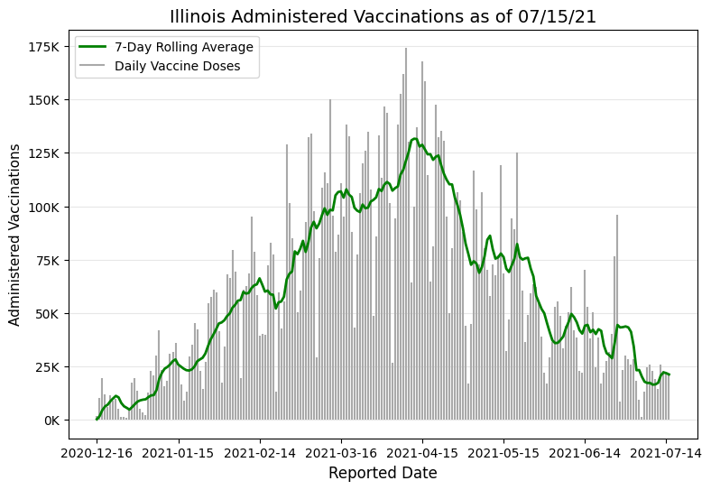

```python
fig, ax = plt.subplots(figsize=(9, 6), dpi=100)
plt.xticks(ticks)

ax.vlines(
    x=vaccinations.index,
    ymin=0,
    ymax=vaccinations["AdministeredCountChange"],
    color="darkgrey",
    alpha=1.0,
    linewidth=1.5,
    label="Daily Vaccine Doses",
)

plt.plot(
    vaccinations["AdministeredCountRollAvg"],
    lw=2,
    color="green",
    label="7-Day Rolling Average",
)

ax.set_title(
    f"Illinois Administered Vaccinations as of {asofMo}/{asofDay}/{asofYr}",
    size=14,
)

plt.grid(axis="y", alpha=0.3)
plt.legend(loc="upper left")
formatter = FuncFormatter(thousands)
ax.yaxis.set_major_formatter(formatter)
ax.set_xlabel("Reported Date", size=12)
ax.set_ylabel("Administered Vaccinations", size=11)
fig.savefig("IL_daily_vaccine.svg", dpi=300, bbox_inches="tight")
```

### Rolling Averages of Daily Administered Vaccines and Fully Vaccinated People

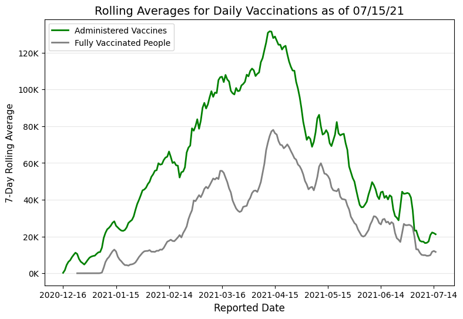

```python
fig, ax = plt.subplots(figsize=(9, 6), dpi=100)

ax.plot(
    vaccinations["AdministeredCountRollAvg"],
    lw=2,
    color="green",
    label="Administered Vaccines",
)


ax.plot(
    vaccinations["PersonsFullyVaccinated"].diff().shift().rolling(7).mean(),
    lw=2,
    color="gray",
    label="Fully Vaccinated People",
)

plt.xticks(ticks)
ax.set_title(
    f"Rolling Averages for Daily Vaccinations as of {asofMo}/{asofDay}/{asofYr}",
    size=14,
)

plt.grid(axis="y", alpha=0.3)
ax.legend(loc="upper left")

ax.set_xlabel("Reported Date", size=12)
ax.set_ylabel("7-Day Rolling Average", size=11)
formatter = FuncFormatter(thousands)
ax.yaxis.set_major_formatter(formatter)

fig.savefig("IL_deaths_and_percent_vacc.svg", dpi=300, bbox_inches="tight")
```

### Total Vaccine Doses Administered and People Fully Vaccinated

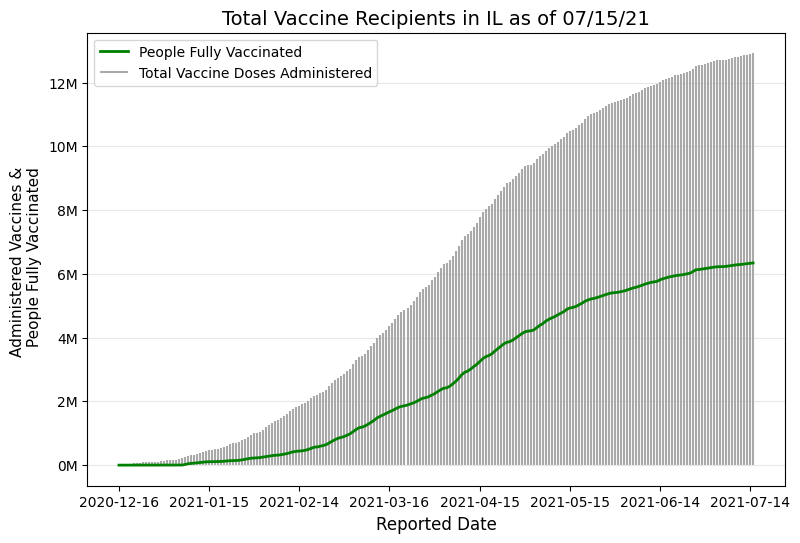

```python
fig, ax = plt.subplots(figsize=(9, 6), dpi=100)
plt.xticks(ticks)

ax.vlines(
    x=vaccinations.index,
    ymin=0,
    ymax=vaccinations["AdministeredCount"],
    color="darkgrey",
    alpha=1.0,
    linewidth=1.5,
    label="Total Vaccine Doses Administered",
)

plt.plot(
    vaccinations["PersonsFullyVaccinated"],
    lw=2,
    color="green",
    label="People Fully Vaccinated",
)

ax.set_title(
    f"Total Vaccine Recipients in IL as of {asofMo}/{asofDay}/{asofYr}",
    size=14,
)

plt.grid(axis="y", alpha=0.3)
plt.legend(loc="upper left")
formatter = FuncFormatter(millions)
ax.yaxis.set_major_formatter(formatter)
ax.set_xlabel("Reported Date", size=12)
ax.set_ylabel("Administered Vaccines & \n People Fully Vaccinated", size=11)
fig.savefig("IL_total_vaccinations.svg", dpi=300, bbox_inches="tight")
```

### Change in Cases with Percent of Vaccinated Residents

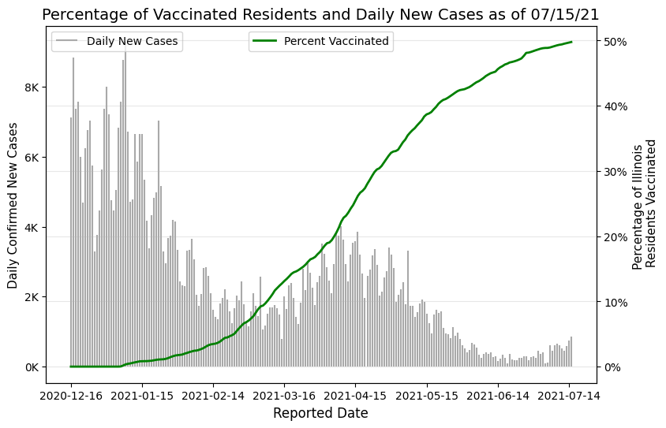

```python
fig, ax = plt.subplots(figsize=(9, 6), dpi=100)

ax.vlines(
    x=cases2.index,
    ymin=0,
    ymax=cases2["CasesChange"],
    color="darkgray",
    alpha=1.0,
    linewidth=1.5,
    label="Daily New Cases",
)

ax2 = ax.twinx()
ax2.plot(
    vaccinations["PercentVaccinated"], lw=2, color="green", label="Percent Vaccinated"
)
plt.xticks(ticks)
ax.set_title(
    f"Percentage of Vaccinated Residents and Daily New Cases as of {asofMo}/{asofDay}/{asofYr}",
    size=14,
)

plt.grid(axis="y", alpha=0.3)
ax.legend(loc="upper left")
ax2.legend(loc="upper center")
formatter = FuncFormatter(thousands)
ax.yaxis.set_major_formatter(formatter)
ax.set_xlabel("Reported Date", size=12)
ax.set_ylabel("Daily Confirmed New Cases", size=11)
formatter = FuncFormatter(percents)
ax2.yaxis.set_major_formatter(formatter)
ax2.set_ylabel("Percentage of Illinois \n Residents Vaccinated", size=11)
fig.savefig("IL_cases_and_percent_vacc.svg", dpi=300, bbox_inches="tight")
```

### Change in Daily Deaths with Percent of Vaccinated Residents

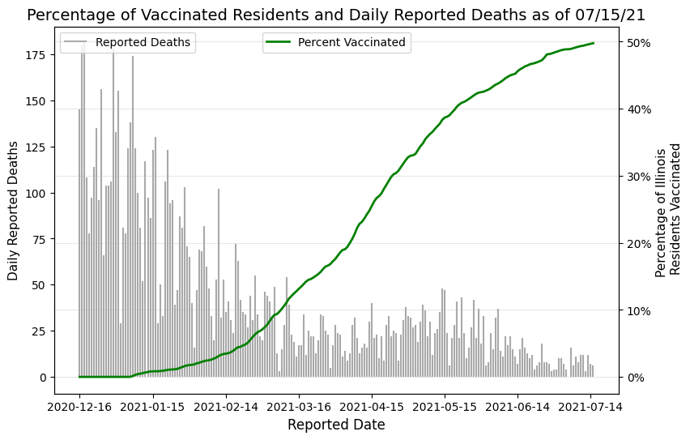

```python
fig, ax = plt.subplots(figsize=(9, 6), dpi=100)

ax.vlines(
    x=cases2.index,
    ymin=0,
    ymax=cases2["DeathsChange"],
    color="darkgray",
    alpha=1.0,
    linewidth=1.5,
    label="Reported Deaths",
)

ax2 = ax.twinx()
ax2.plot(
    vaccinations["PercentVaccinated"], lw=2, color="green", label="Percent Vaccinated"
)

plt.xticks(ticks)
ax.set_title(
    f"Percentage of Vaccinated Residents and Daily Reported Deaths as of {asofMo}/{asofDay}/{asofYr}",
    size=14,
)

plt.grid(axis="y", alpha=0.3)
ax.legend(loc="upper left")
ax2.legend(loc="upper center")
ax.set_xlabel("Reported Date", size=12)
ax.set_ylabel("Daily Reported Deaths", size=11)
formatter = FuncFormatter(percents)
ax2.yaxis.set_major_formatter(formatter)
ax2.set_ylabel("Percentage of Illinois \n Residents Vaccinated", size=11)
fig.savefig("IL_deaths_and_percent_vacc.svg", dpi=300, bbox_inches="tight")
```

### Summary

We can see from the first graphic that the number of daily administered vaccinations grew steadily until mid April when a sharp decline occured in the number of new doses administered. Note that this decline in daily new vaccinations corresponds with the suspension and re-approval of the Johnson & Johnson vaccine. From the second graphic of the rolling average in daily administered vaccines and new fully vaccinated people we can see that the decline in administered vaccines closely parallels the decline in new fully vaccinated people. Since the Johnson & Johnson vaccine is a single dose vaccine and a suspension of this vaccine would have an immediate effect on the number of new fully vaccinated people, the second graphic further suggests that these declines in administered vaccines and new fully vaccinated people corresponds with the suspension of the Johnson & Johnson vaccine. From the third graphic of total vaccine recipients it is clear that the number of fully vaccinated people is growing along with the total vaccine doses administered, this suggests that vaccine recipients are returning for their second dose.

In the fourth graphic, relating the daily confirmed new cases with the percentage of Illinois residents who have been fully vaccinated we can see that despite the growth in the percentage of vaccinated residents, there was a temporary increase in the number of daily new cases. This spike in cases could be for a variety of reasons such as changes in weather or public policy regarding indoor spaces which would lead to an increase in mobility, or from the introduction of a virus variant from a different country.

Looking at the fifth graphic, a comparison of daily reported deaths related to COVID-19 and the percentage of fully vaccinated residents we can see a dramatic decrease in the number of daily COVID-19 related deaths. However, this comparison between the vaccination percentages and the number of reported deaths is limited, we must investigate further the relation between the number of fully vaccinated people, the number of new cases, and the daily reported deaths.